# Differential expression analysis

John Blischak

Genomics and Sytems Biology, University of Chicago

Date: 2021-08-24

In this tutorial, we will perform a basic differential expression analysis with RNA sequencing data using R/Bioconductor. Before class, please download the data set and install the software as explained in the following section.

## Download data and install software

For this tutorial, we will use the data set generated by the Sequencing Quality Control ([SEQC](http://www.fda.gov/ScienceResearch/BioinformaticsTools/MicroarrayQualityControlProject/)) project. Please download the data by running the line of R code below. If this fails, you can try changing the `method` parameter, e.g. `method = "auto"`, `method = "wget"` or `method = "curl"`. And as a last resort, you can download it by clicking on this [link](https://www.ncbi.nlm.nih.gov/geo/download/?acc=GSE49712&format=file&file=GSE49712_HTSeq.txt.gz).

```r
fname <- "https://www.ncbi.nlm.nih.gov/geo/download/?acc=GSE49712&format=file&file=GSE49712_HTSeq.txt.gz"
download.file(fname, destfile = "GSE49712_HTSeq.txt.gz", method = "curl")
```

Next, we need to download and install the two [Bioconductor](http://www.bioconductor.org) packages we will use to perform the analysis.

```r
source("http://bioconductor.org/biocLite.R")
biocLite(c("edgeR", "DESeq2"))
```

## Introduction

As you learned in class, RNA sequencing (RNA-seq) is an experimental method for measuring RNA expression levels via high-throughput sequencing of small adapter-ligated fragments (see figure below from Wang, Gerstein, and Snyder (2009)). The number of reads that map to a gene is the proxy for its expression level.

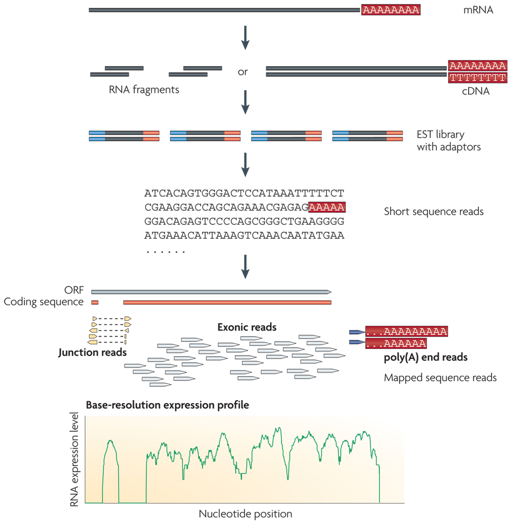

RNA-seq experiment

There are many steps between receiving the raw reads from the sequencer and gaining biological insight. In this tutorial, we will start with a “Table of counts” and end with a “List of differentially expressed genes”, as diagrammed in the RNA-seq analysis pipeline below (from Oshlack, Robinson, and Young (2010)).

[figure not shown]

RNA-seq analysis pipeline

Unlike the continuous data that is generated by microarrays, RNA-seq generates counts. While it is possible to transform the counts into a continuous distribution and perform an analysis similar to microarrays, e.g. linear regression, multiple approaches have been developed to directly model the data as counts (Marioni, Mason, Mane, Stephens, and Gilad (2008)). We will perform a simple analysis using two very popular Bioconductor packages for differential expression analysis, [edgeR](http://www.bioconductor.org/packages/release/bioc/html/edgeR.html) and [DESeq2](http://bioconductor.org/packages/release/bioc/html/DESeq2.html).

The SEQC data set will we analyze contains two different groups for comparison. Group A is five technical replicates of the [Stratagene Universal Human Reference RNA](http://www.chem.agilent.com/Library/usermanuals/Public/740000.pdf). It is an equal mixture of RNA from ten different human cell lines. Group B is five techincal replicates of [Ambion’s Human Brain Reference RNA](http://www.lifetechnologies.com/order/catalog/product/AM6050). It is RNA that was pooled from several donors from several different regions of the brain.

## edgeR

edgeR (Robinson and Smyth (2007); Robinson, McCarthy, and Smyth (2009)) models the count data with a [negative binomial model](http://en.wikipedia.org/wiki/Negative_binomial_distribution).

First, we need to load the package into R.

```r
library("edgeR")
```

Second, we need to load the data into R. In order to use the code below, we need to ensure the data file is in R’s working directory. We can check our current working directory with the command `getwd()`, and we can change it using `setwd("path/to/file")` or using RStudio (type Ctrl-Shift-K).

```r
data_raw <- read.table("GSE49712_HTSeq.txt.gz", header = TRUE)
```

Let’s quickly explore the data. Each column corresponds to a sample, and each row corresponds to a gene.

```r
dim(data_raw)
```

```
## [1] 21716    10
```

```r
head(data_raw)
```

```
##               A_1   A_2   A_3   A_4   A_5   B_1   B_2   B_3   B_4  B_5
## 1/2-SBSRNA4    74    51    36    66    34    39    41    33    35   18
## A1BG          194   315   195   274   456   138   128   175   147  171
## A1BG-AS1      128   129    79   145    82   115   137   100   102   45
## A1CF         1360  1139   780  1552  1011     6     7     3     3    2
## A2LD1         161   144    98   247   166   101    79   115    99   82
## A2M         46752 42968 27571 55019 32594 13396 14316 14391 11543 7600
```

```r
tail(data_raw)
```

```
##                           A_1      A_2      A_3      A_4      A_5      B_1
## tAKR                        0        0        0        1        0        4
## no_feature           17112284 14987239 10299327 19998641 10061200 18653286
## ambiguous             1429745  1318247   887845  1808331  1059290   912480
## too_low_aQual               0        0        0        0        0        0
## not_aligned                 0        0        0        0        0        0
## alignment_not_unique  8773459  7623586  5351098 10654226  6066807  8939863
##                           B_2      B_3      B_4     B_5
## tAKR                        3       10        3       2
## no_feature           19383713 19996921 16497815 9490982
## ambiguous              954186   956121   803816  533877
## too_low_aQual               0        0        0       0
## not_aligned                 0        0        0       0
## alignment_not_unique  9215458  9166078  7682474 4987468
```

Notice that the last five lines contain summary statistics and thus need to be removed prior to testing.

```r
data_clean <- data_raw[1:(nrow(data_raw) - 5), ]
```

We should also remove genes that are unexpressed or very lowly expressed in the samples. One simple method to do this is to choose a cutoff based on the median log2-transformed counts per gene per million mapped reads (cpm). edgeR provides the function, `cpm`, to compute the counts-per-million.

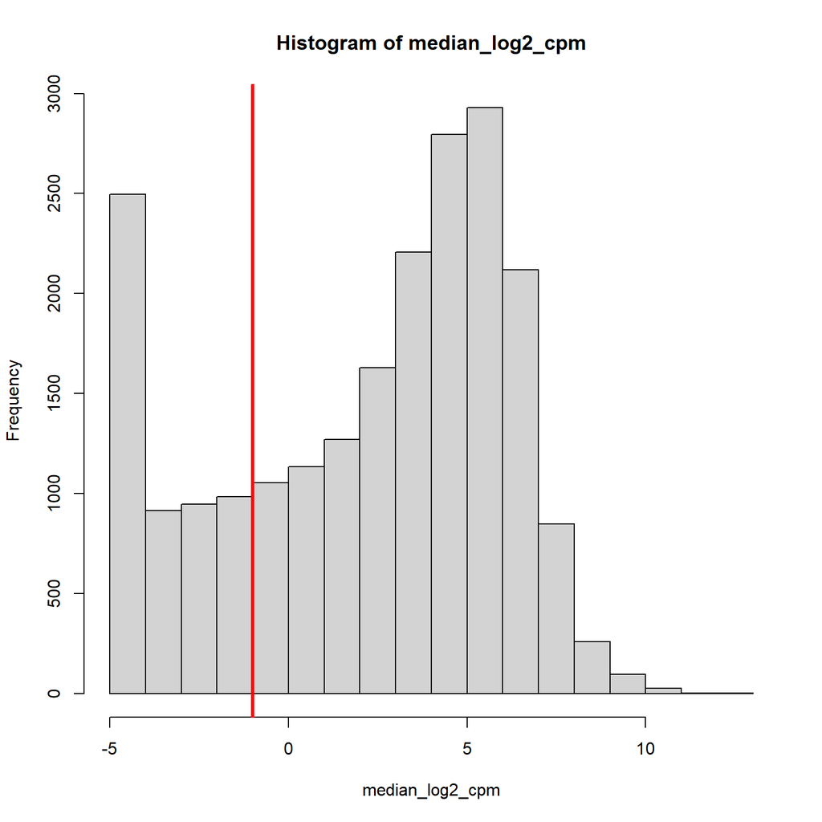

```r
median_log2_cpm <- apply(cpm(data_clean, log = TRUE), 1, median)
hist(median_log2_cpm)
expr_cutoff <- -1
abline(v = expr_cutoff, col = "red", lwd = 3)
```

```r
sum(median_log2_cpm > expr_cutoff)
```

```
## [1] 16371
```

```r
data_clean <- data_clean[median_log2_cpm > expr_cutoff, ]
```

After removing all genes with a median log2 cpm below -1, we have 16371 genes remaining. A good rule of thumb when analyzing RNA-seq data from a single cell type is to expect 9-12 thousand expressed genes. In this case, we have many more because the samples include RNA collected from many different cell types, and thus it is not surprising that many more genes are robustly expressed.

**Question:** What are some ways that we could improve this simple cutoff? What information are we ignoring?

We can also explore the relationships between the samples by visualizing a heatmap of the correlation matrix. The heatmap result corresponds to what we know about the data set. First, the samples in group A and B come from very different cell populations, so the two groups are very different. Second, since the samples in each group are technical replicates, the within group variance is very low.

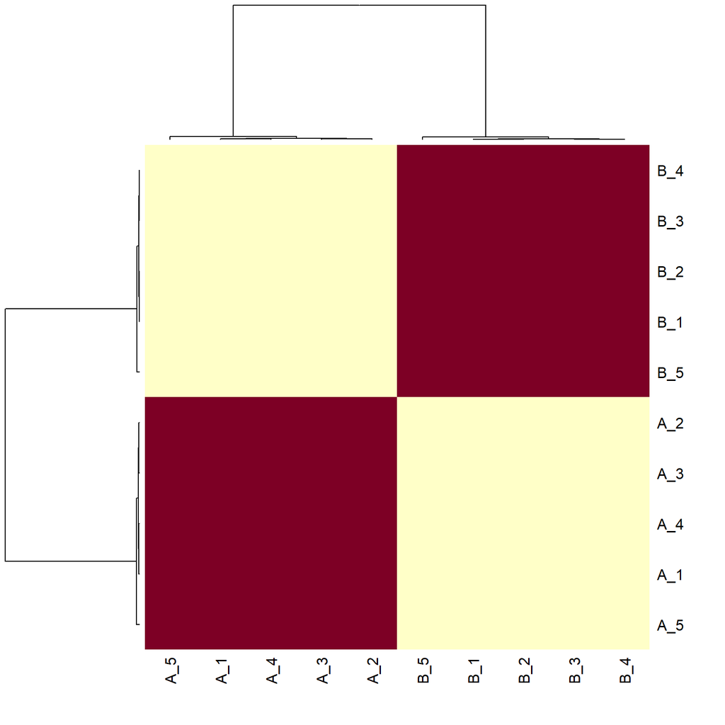

```r
heatmap(cor(cpm(data_clean, log = TRUE)))
```

Now we start preparing the data for the the test of differential expression. We create a vector called, `group`, that labels each of the columns as belonging to group A or B. We then use this vector and the gene counts to create a DGEList, which is the object that edgeR uses for storing the data from a differntial expression experiment.

```r
group <- substr(colnames(data_clean), 1, 1)
group
```

```
##  [1] "A" "A" "A" "A" "A" "B" "B" "B" "B" "B"
```

```r
y <- DGEList(counts = data_clean, group = group)
y
```

```
## An object of class "DGEList"
## $counts
##              A_1  A_2 A_3  A_4  A_5 B_1 B_2 B_3 B_4 B_5
## 1/2-SBSRNA4   74   51  36   66   34  39  41  33  35  18
## A1BG         194  315 195  274  456 138 128 175 147 171
## A1BG-AS1     128  129  79  145   82 115 137 100 102  45
## A1CF        1360 1139 780 1552 1011   6   7   3   3   2
## A2LD1        161  144  98  247  166 101  79 115  99  82
## 16366 more rows ...
##
## $samples
##     group lib.size norm.factors
## A_1     A 63518286            1
## A_2     A 58473717            1
## A_3     A 39099712            1
## A_4     A 78490525            1
## A_5     A 48611262            1
## B_1     B 62749592            1
## B_2     B 65979710            1
## B_3     B 66142599            1
## B_4     B 55042500            1
## B_5     B 37726512            1
```

edgeR normalizes the genes counts using the method TMM (trimmed means of m values) developed by Robinson and Oshlack (2010). Recall from lecture that the read counts for moderately to lowly expressed genes can be strongly influenced by small fluctuations in the expression level of highly expressed genes. In other words, small differences in expression of highly expressed genes between samples can give the appearance that many lower expressed genes are differentially expressed between conditions. TMM adjusts for this by removing the extremely lowly and highly expressed genes and also those genes that are very different across samples. It then compares the total counts for this subset of genes between the two samples to get the scaling factor (this is a simplification). Similar to normalization methods for microarray data, this method assumes the majority of genes are not differentially expressed between any two samples.

```r
y <- calcNormFactors(y)
y$samples
```

```
##     group lib.size norm.factors
## A_1     A 63518286    1.0327337
## A_2     A 58473717    1.0425468
## A_3     A 39099712    1.0653268
## A_4     A 78490525    1.0186905
## A_5     A 48611262    1.0878793
## B_1     B 62749592    0.9551043
## B_2     B 65979710    0.9512470
## B_3     B 66142599    0.9576923
## B_4     B 55042500    0.9532482
## B_5     B 37726512    0.9484930
```

The next step is to model the variance of the read counts per gene. A natural method for modeling gene counts is the Poisson distribution. However, the Poisson assumes the mean and variance are identical, but it has been found emipirically that the variance in RNA-seq measurements of gene expression are larger than the mean (termed “overdispersion”). So instead the negative binomial distribution is used, which has a dispersion parameter for modeling the increase in variance from a Poisson process. edgeR treats the Poisson variance as simple sampling variance, and refers to the dispersion estimate as the “biolocial coefficient of variation.” Though it should be mentioned that any technical biases are also included in this estimate. edgeR shares information across genes to determine a common dispersion. It then calculates a dispersion esitmate per gene and shrinks it towards the common dispersion. The gene-specific (referred to in edgeR as tagwise) dispersion estimates are used in the test for differential expression.

**Note:** edgeR also has a trended dispersion to use in place of the common dispersion for more complicated experimental designs.

```r
y <- estimateCommonDisp(y, verbose = TRUE)
```

```
## Disp = 0.0134 , BCV = 0.1158
```

```r
y <- estimateTagwiseDisp(y)
sqrt(y$common.dispersion) # biological coefficient of variation
```

```
## [1] 0.1157583
```

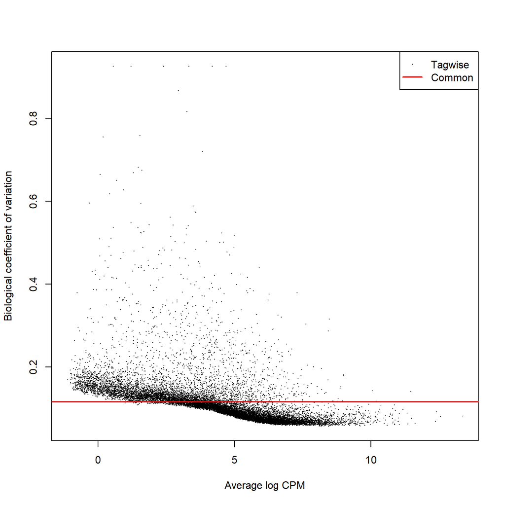

```r
plotBCV(y)
```

The biological coefficient of variation is lower than normally seen in human studies (~0.4) because the samples are technical replicates.

edgeR tests for differential expression between two classes using a modified version of the Fisher’s Exact Test.

**Note:** It also provides a generalized linear model frameworks for more complicated experimental designs.

```r
et <- exactTest(y)
results_edgeR <- topTags(et, n = nrow(data_clean), sort.by = "none")
head(results_edgeR$table)
```

```
##                  logFC     logCPM        PValue           FDR
## 1/2-SBSRNA4 -0.5152730 -0.3725671  1.058709e-02  1.233691e-02
## A1BG        -0.7646065  1.9820123  4.900663e-03  5.808627e-03
## A1BG-AS1    -0.0583282  0.9017730  7.076611e-01  7.231209e-01
## A1CF        -7.9422676  3.2922627  0.000000e+00  0.000000e+00
## A2LD1       -0.6012543  1.1826177  4.593776e-04  5.683549e-04
## A2M         -1.6064573  8.8124411 1.930454e-152 1.064089e-151
```

How many genes are differentially expressed at an FDR of 10%?

```r
sum(results_edgeR$table$FDR < .1)
```

```
## [1] 14852
```

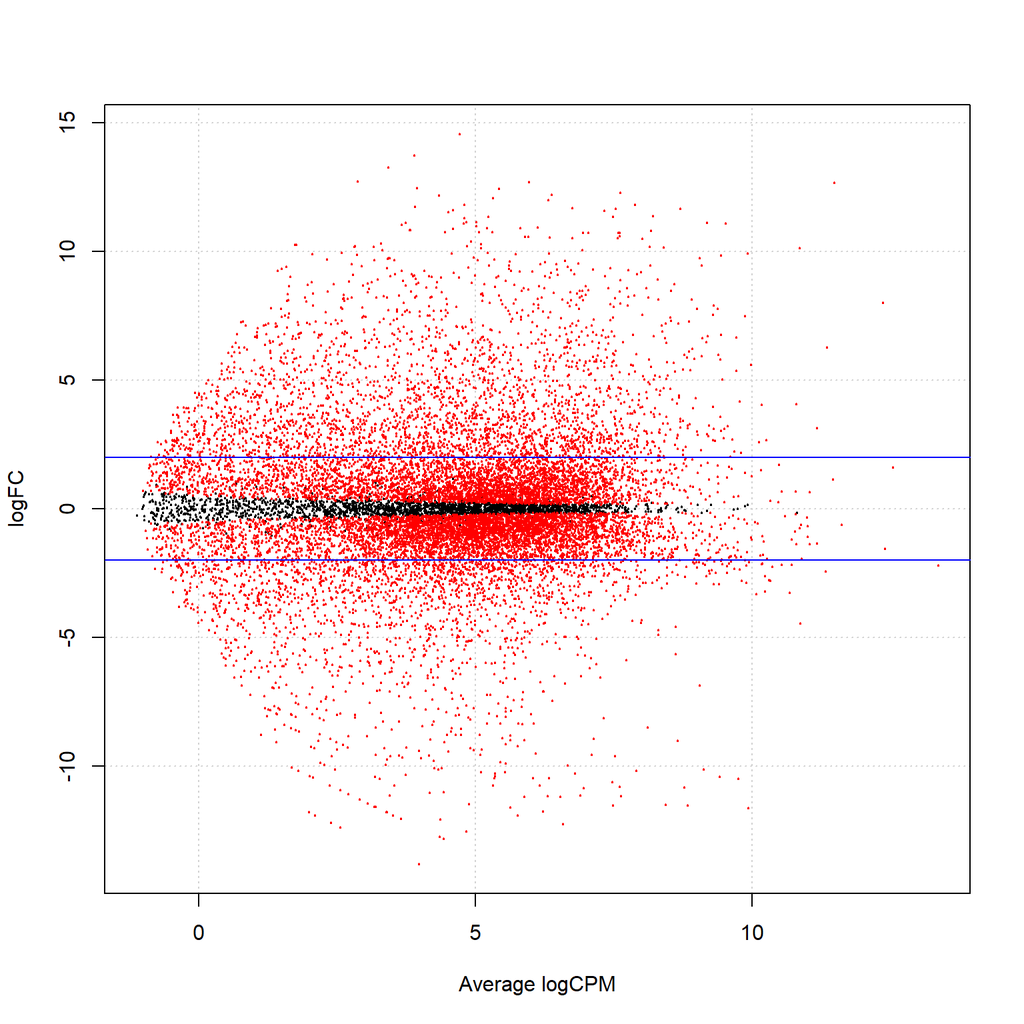

```r
plotSmear(et, de.tags = rownames(results_edgeR)[results_edgeR$table$FDR < .01])
abline(h = c(-2, 2), col = "blue")
```

## DESeq2

DESeq2 also models the gene counts as arising from a [negative binomial distribution](http://en.wikipedia.org/wiki/Negative_binomial_distribution).

```r
library("DESeq2")
dds <- DESeqDataSetFromMatrix(data_clean, as.data.frame(group), ~ group)
dds
```

```
## class: DESeqDataSet
## dim: 16371 10
## metadata(1): version
## assays(1): counts
## rownames(16371): 1/2-SBSRNA4 A1BG ... ZZZ3 psiTPTE22
## rowData names(0):
## colnames(10): A_1 A_2 ... B_4 B_5
## colData names(1): group
```

For data exploration, the DESeq2 package provides a more sophisticated version of edgeR’s `cpm` function which shrinks the dispersion for lowly expressed genes. The function is called `rlog`, for **r**egularlized **log** transformation.

**Note:** `rlog` is a newer feature and may not be available for older versions of R.

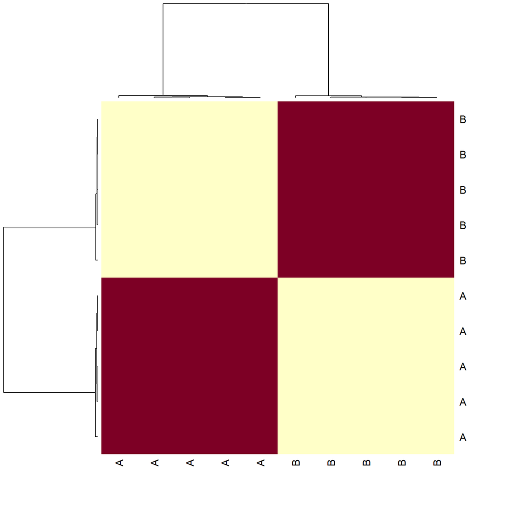

```r
rld <- rlog(dds)
rlogMat <- assay(rld)
colnames(rlogMat) <- group
heatmap(cor(rlogMat))
```

Similar to edgeR, DESeq2 assumes that most genes are not differentially expressed. Each sample is assigned a scaling factor which is computed by comparing the gene counts of the sample to the median gene counts of all the samples combined (Anders and Huber (2010)).

```r
dds <- estimateSizeFactors(dds)
```

For the dispersion, DESeq2 fits gene-wise dispersion estimates and then shrinks them towards a trended dispersion estimated by sharing information across genes. We can see in the figure below that the dispersion estimates are shrunk towards the red trend line.

```r
dds <- estimateDispersions(dds)
```

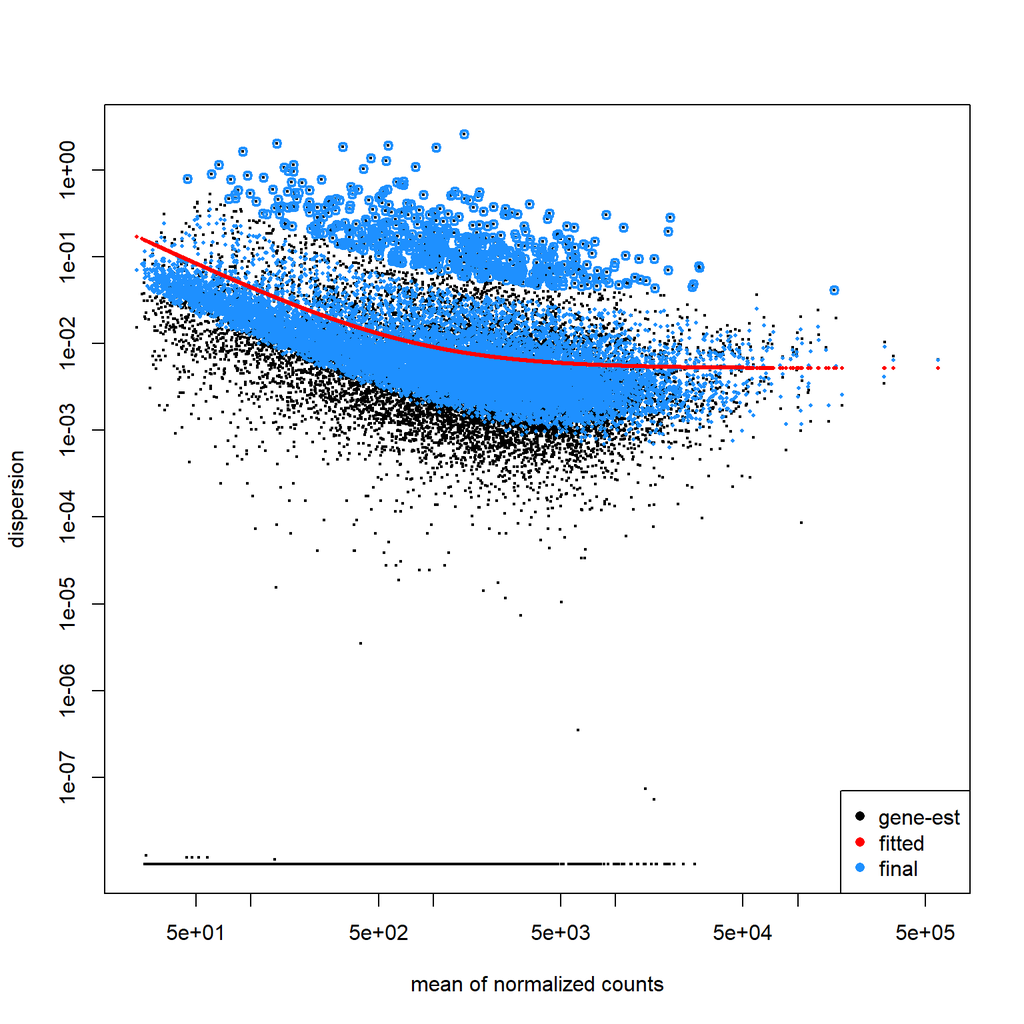

```r
plotDispEsts(dds)
```

For testing for differentially expressed genes, DESeq2 uses a negative binomial generalized linear model (GLM).

**Note:** This GLM allows for more complicated experimental designs.

```r
dds <- nbinomWaldTest(dds)
results_DESeq2 <- results(dds)
results_DESeq2
```

```
## log2 fold change (MLE): group B vs A
## Wald test p-value: group B vs A
## DataFrame with 16371 rows and 6 columns
##              baseMean log2FoldChange     lfcSE       stat       pvalue
##             <numeric>      <numeric> <numeric>  <numeric>    <numeric>
## 1/2-SBSRNA4   40.9391     -0.4924994  0.231019  -2.131853  3.30189e-02
## A1BG         222.0295     -0.7458856  0.286714  -2.601493  9.28190e-03
## A1BG-AS1     102.3870     -0.0344933  0.169489  -0.203514  8.38733e-01
## A1CF         541.3768     -7.9579026  0.322024 -24.712169 7.91397e-135
## A2LD1        125.3632     -0.5785143  0.172247  -3.358633  7.83291e-04
## ...               ...            ...       ...        ...          ...
## ZYG11B        6755.95       1.950946 0.0610572   31.95274 4.94986e-224
## ZYX           6209.97       0.175360 0.0884106    1.98347  4.73145e-02
## ZZEF1         4229.65       0.719226 0.0628661   11.44059  2.62096e-30
## ZZZ3          2229.12      -0.442787 0.0458083   -9.66607  4.20193e-22
## psiTPTE22      441.61      -2.115641 0.0861831  -24.54822 4.51861e-133
##                     padj
##                <numeric>
## 1/2-SBSRNA4  3.68692e-02
## A1BG         1.06134e-02
## A1BG-AS1     8.47931e-01
## A1CF        3.18216e-134
## A2LD1        9.36471e-04
## ...                  ...
## ZYG11B      2.91893e-223
## ZYX          5.23304e-02
## ZZEF1        4.83342e-30
## ZZZ3         7.04654e-22
## psiTPTE22   1.79917e-132
```

How many genes are differentially expressed at an FDR of 10%?

```r
sum(results_DESeq2@listData$padj < .1, na.rm = TRUE)
```

```
## [1] 14998
```

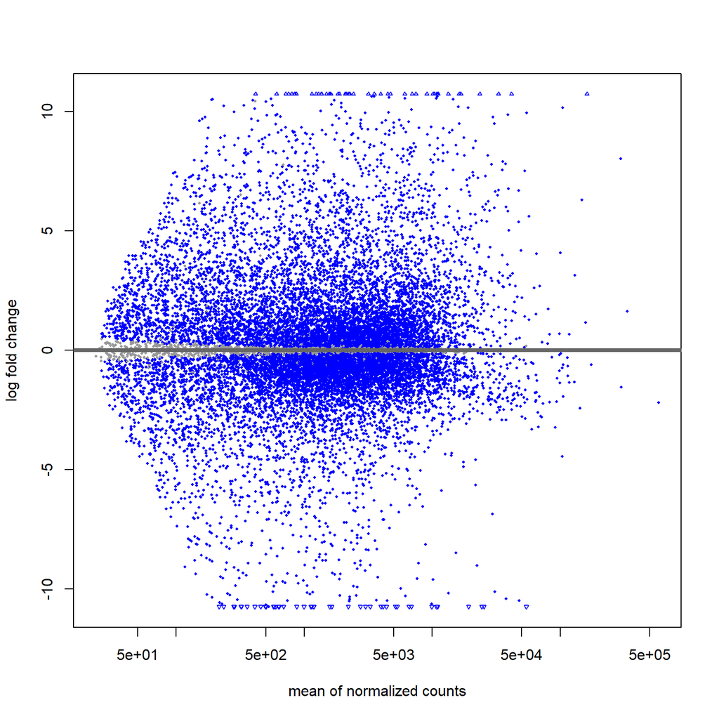

```r
plotMA(results_DESeq2)
```

DESeq2 also provides a convenience function that will perform the normalization, modeling, and testing steps.

```r
dds <- DESeq(dds)
```

```
## found already estimated dispersions, replacing these
```

```r
res <- results(dds)
res
```

```
## log2 fold change (MLE): group B vs A
## Wald test p-value: group B vs A
## DataFrame with 16371 rows and 6 columns
##              baseMean log2FoldChange     lfcSE       stat       pvalue
##             <numeric>      <numeric> <numeric>  <numeric>    <numeric>
## 1/2-SBSRNA4   40.9391     -0.4924994  0.231019  -2.131853  3.30189e-02
## A1BG         222.0295     -0.7458856  0.286714  -2.601493  9.28190e-03
## A1BG-AS1     102.3870     -0.0344933  0.169489  -0.203514  8.38733e-01
## A1CF         541.3768     -7.9579026  0.322024 -24.712169 7.91397e-135
## A2LD1        125.3632     -0.5785143  0.172247  -3.358633  7.83291e-04
## ...               ...            ...       ...        ...          ...
## ZYG11B        6755.95       1.950946 0.0610572   31.95274 4.94986e-224
## ZYX           6209.97       0.175360 0.0884106    1.98347  4.73145e-02
## ZZEF1         4229.65       0.719226 0.0628661   11.44059  2.62096e-30
## ZZZ3          2229.12      -0.442787 0.0458083   -9.66607  4.20193e-22
## psiTPTE22      441.61      -2.115641 0.0861831  -24.54822 4.51861e-133
##                     padj
##                <numeric>
## 1/2-SBSRNA4  3.68692e-02
## A1BG         1.06134e-02
## A1BG-AS1     8.47931e-01
## A1CF        3.18216e-134
## A2LD1        9.36471e-04
## ...                  ...
## ZYG11B      2.91893e-223
## ZYX          5.23304e-02
## ZZEF1        4.83342e-30
## ZZZ3         7.04654e-22
## psiTPTE22   1.79917e-132
```

## Comparison

How similar are the FDR values obtained with edgeR and DESeq2?

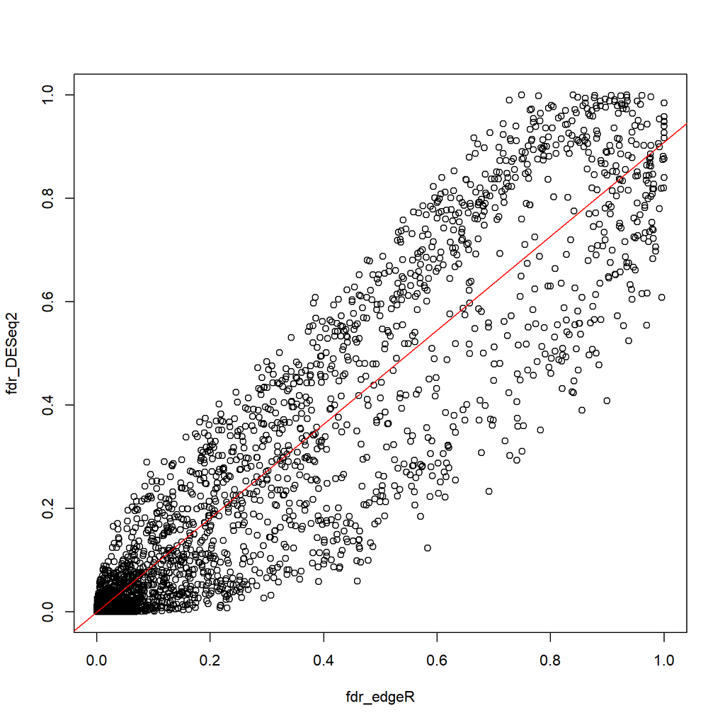

```r
fdr_edgeR <- results_edgeR$table$FDR
fdr_DESeq2 <- results_DESeq2@listData$padj
plot(fdr_edgeR, fdr_DESeq2)
abline(lm(fdr_DESeq2 ~ fdr_edgeR), col = "red")
```

For a more rigorous comparison of these and other methods, see (Rapaport, Khanin, Liang, Pirun, Krek, Zumbo, Mason, Socci, and Betel, 2013; Soneson and Delorenzi, 2013).

## To learn more

Check out the manuals for [edgeR](http://www.bioconductor.org/packages/release/bioc/vignettes/edgeR/inst/doc/edgeRUsersGuide.pdf) and [DESeq2](http://www.bioconductor.org/packages/release/bioc/vignettes/DESeq2/inst/doc/DESeq2.pdf), search the Bioconductor mailing list [archives](http://dir.gmane.org/gmane.science.biology.informatics.conductor), and consider joining the Bioconductor mailing [list](http://www.bioconductor.org/help/mailing-list/). The [source code](https://gist.github.com/jdblischak/11384914) for this lesson is availabe as a GitHub Gist.

## References

[1] S. Anders and W. Huber. “Differential expression analysis for sequence count data”. In: *Genome Biology* 11.10 (oct.. 2010). DOI: 10.1186/gb-2010-11-10-r106. URL: https://doi.org/10.1186/gb-2010-11-10-r106.

[2] J. C. Marioni, C. E. Mason, S. M. Mane, et al. “RNA-seq: An assessment of technical reproducibility and comparison with gene expression arrays”. In: *Genome Research* 18.9 (jul.. 2008), pp. 1509–1517. DOI: 10.1101/gr.079558.108. URL: https://doi.org/10.1101/gr.079558.108.

[3] A. Oshlack, M. D. Robinson, and M. D. Young. “From RNA-seq reads to differential expression results”. In: *Genome Biology* 11.12 (2010), p. 220. DOI: 10.1186/gb-2010-11-12-220. URL: https://doi.org/10.1186/gb-2010-11-12-220.

[4] F. Rapaport, R. Khanin, Y. Liang, et al. “Comprehensive evaluation of differential gene expression analysis methods for RNA-seq data”. In: *Genome Biology* 14.9 (2013), p. R95. DOI: 10.1186/gb-2013-14-9-r95. URL: https://doi.org/10.1186/gb-2013-14-9-r95.

[5] M. D. Robinson, D. J. McCarthy, and G. K. Smyth. “edgeR: a Bioconductor package for differential expression analysis of digital gene expression data”. In: *Bioinformatics* 26.1 (nov.. 2009), pp. 139–140. DOI: 10.1093/bioinformatics/btp616. URL: https://doi.org/10.1093/bioinformatics/btp616.

[6] M. D. Robinson and A. Oshlack. “A scaling normalization method for differential expression analysis of RNA-seq data”. In: *Genome Biology* 11.3 (2010), p. R25. DOI: 10.1186/gb-2010-11-3-r25. URL: https://doi.org/10.1186/gb-2010-11-3-r25.

[7] M. D. Robinson and G. K. Smyth. “Moderated statistical tests for assessing differences in tag abundance”. In: *Bioinformatics* 23.21 (sep.. 2007), pp. 2881–2887. DOI: 10.1093/bioinformatics/btm453. URL: https://doi.org/10.1093/bioinformatics/btm453.

[8] C. Soneson and M. Delorenzi. “A comparison of methods for differential expression analysis of RNA-seq data”. In: *BMC Bioinformatics* 14.1 (mar.. 2013). DOI: 10.1186/1471-2105-14-91. URL: https://doi.org/10.1186/1471-2105-14-91.

[9] Z. Wang, M. Gerstein, and M. Snyder. “RNA-Seq: a revolutionary tool for transcriptomics”. In: *Nature Reviews Genetics* 10.1 (ene.. 2009), pp. 57–63. DOI: 10.1038/nrg2484. URL: https://doi.org/10.1038/nrg2484.